# Comparative Analysis of Airbnb Price Distributions in Paris, New York, and Sydney

Final Project  
Data Science 1 with R (STAT 301-1)

Author

Hailee Kim

Published

December 11, 2024

**Github Repo Link**

[Hailee’s Final Project Github Repo (hailee-kim)](https://github.com/hailee-kim/final-project-1-hailee-kim.git)

## Introduction

I selected the **Airbnb listings dataset** inspired by my recent Thanksgiving trip to Joshua Tree National Park, where I used Airbnb for accommodations. My recent travels across North America and Canada using Airbnb have not only familiarized me with its system but also piqued my interest in the underlying dynamics of the service. This analysis aims to explore key patterns and relationships in Airbnb listing data, guided by research questions such as:

- What is the distribution of Airbnb listing prices in each city, and what patterns can be observed within these distributions?
- Are there outliers or significant differences in price ranges across cities?
- How do various features such as the number of guests accommodated, number of bedrooms, and minimum nights per booking correlate with listing prices? Which features have the strongest relationship with price, and does this relationship vary by city?

The dataset was sourced from **Maven Analytics**, a reputable provider of data training and datasets. The datasets were freely available on a resource page titled “Data Playground.”[^1] This dataset includes all the necessary information for conducting exploratory data analysis, eliminating the need for merging additional datasets.

<sup>1</sup> This dataset was sourced from [Maven Analytics](https://www.mavenanalytics.io/data-playground), accessed on November 3rd, 2024.

## Data Overview & quality

The dataset comprises **279,712 observations** across **33 variables**, including 1 date variable, 9 categorical variables (originally character, converted to factors), 4 logical variables, and 19 numeric variables. Certain variables, such as district (`district`), estimate of how long the Host takes to respond (`host_response_time`), and rating data (`review_scores_rating`, `review_scores_accuracy`…), exhibit low completeness with a significant proportion of missing values, necessitating careful consideration during analysis.

The dataset is generally tidy, **except for the amenities attribute**, which contains a list of amenities (e.g., [“Heating”, “Kitchen”, “Washer”, “Wifi”, “Long term stays allowed”]). To address this, I transformed each amenity into a separate binary column to indicate its presence (1) or absence (0) in each listing.

For analysis, prices were compared within the same city to maintain consistency and avoid complications arising from **variations in local currencies**. This approach enables meaningful bivariate and multivariate analyses, focusing on relationships between price and variables such as accommodates, bedrooms, and minimum nights per booking.

## Univariate Analysis

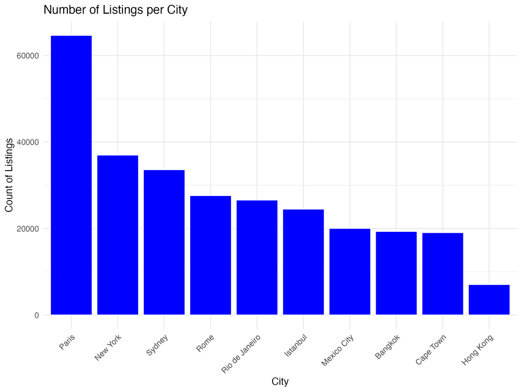

Figure 1: Paris has the highest number of listings at 64,690, followed by New York with 37,012, and Sydney with 33,630

As shown in Figure 1, the univariate analysis of the city variable shows that there are **10 distinct cities** listed in the dataset. **Paris, New York, and Sydney** emerged as the top three cities with the highest number of listings, collectively representing a significant portion of the total data. Given the overall dataset encompasses **279,712 listings**, with these three cities alone accounting for **135,332 listings**, which is **48%** of the total, a strategic decision was made to focus my analysis on these locations.

### Paris

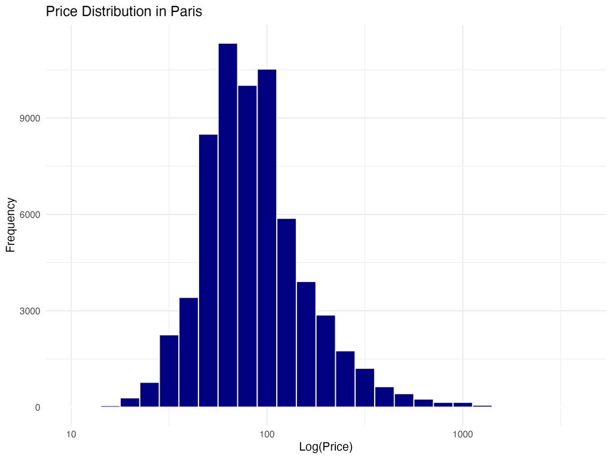

Figure 2: Log-transformed price distribution in Paris, with the majority of values centered around the 10-100 range

### New York

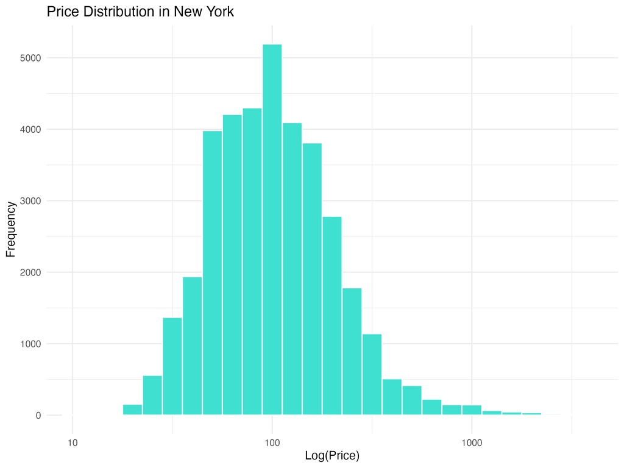

Figure 3: Log-transformed price distribution in New York, showcasing a broader spread with a peak near 100

### Sydney

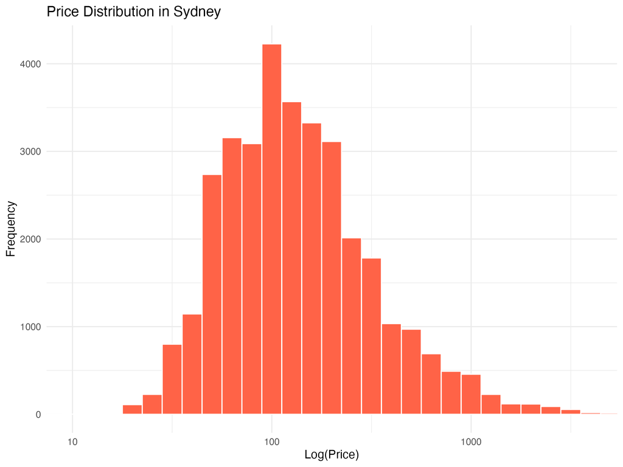

Figure 4: Log-transformed price distribution in Sydney, indicating a moderate spread with prices concentrated near 100

Figure 2, Figure 3, and Figure 4 show the right-skewed log-transformed price distributions for selected cities: Paris, New York, and Sydney. Figure 2 indicates that in **Paris**, the distribution is approximately symmetric, with a clear peak around the center, suggesting that most prices are concentrated within a relatively narrow range. **New York**’s distribution, while also centered, shows a broader spread and a slightly flatter peak, indicating a wider variety of prices and a more diverse market as shown in Figure 3. In contrast, in Figure 4, **Sydney**’s distribution resembles New York’s in its broader shape but has a slightly lower peak, reflecting a moderate concentration of prices and an even distribution across the range. These shapes highlight the unique pricing dynamics in each city, with Paris displaying a more centralized pattern, while New York and Sydney show greater variability.

## Bivariate Analysis

Table 1: Summary Statistics for Price within Each City

| city | mean_price | median_price | sd_price | min_price | max_price | n |
| --- | --- | --- | --- | --- | --- | --- |
| Paris | 113.0964 | 80 | 214.4337 | 0 | 12000 | 64690 |
| New York | 142.8422 | 99 | 275.7410 | 0 | 10000 | 37012 |
| Sydney | 222.0134 | 120 | 472.6362 | 5 | 28613 | 33630 |

Table 1 summarizes mean, median, standard deviation, minimum, and maximum prices for Airbnb listings across top 3 cities. **Sydney** has the highest average price (mean: 222.01) and the largest variability, with a standard deviation of 472.63, indicating a highly diverse pricing landscape. This variability is reflected in the large range between the minimum price (5) and maximum price (28,613), suggesting the presence of both affordable and luxury pricing segments. **Paris**, in contrast, has a much lower mean price of 113.10 and a smaller standard deviation of 214.43. The relatively small spread suggests a more homogenous pricing structure, where prices are concentrated closer to the median of 80. **New York** falls in between, with a mean price of 142.84 and a standard deviation of 275.74. Its median price of 99 is slightly higher than Paris, but the broader spread indicates a market with a moderate level of diversity.

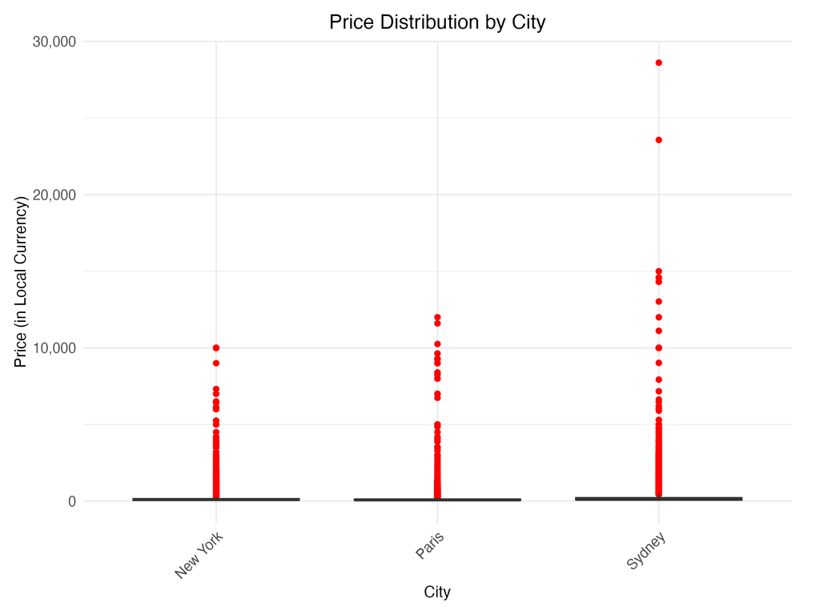

Figure 5: Visualization of price distributions across cities, highlighting disparities, variability, and the impact of outliers on pricing trends

## Multivariate Analysis

To further explore the factors influencing price across New York, Paris, and Sydney, we examine the correlations between price and selected variables: number of accommodations, number of bedrooms, minimum nights, latitude, and longitude. Table 2 provides the numerical correlations, while Figure 6 visualizes these relationships.

Table 2: Correlations Between Price and Selected Variables by Top 3 Cities

| city | cor_accommodates | cor_bedrooms | cor_minimum_nights | cor_latitude | cor_longtitude |
| --- | --- | --- | --- | --- | --- |
| New York | 0.2765372 | 0.2514875 | 0.0230943 | 0.0199511 | -0.1011703 |
| Paris | 0.2745516 | 0.2014397 | 0.0020665 | -0.0181164 | -0.0793692 |
| Sydney | 0.3668660 | 0.3931546 | 0.0278050 | 0.1325530 | 0.1220082 |

As shown in Table 2, the number of people a **property accommodates and the number of bedrooms are positively correlated** with price across all three cities. Sydney exhibits the strongest correlation for both variables, with accommodates at 0.37 and bedrooms at 0.39. This suggests that larger properties command higher prices, particularly in Sydney, where market trends might favor spacious accommodations. New York and Paris show similar, albeit **slightly weaker**, correlations (accomodates at ~0.27 and bedrooms at ~0.25 and 0.20, respectively). This indicates that while size impacts price, the effect is less pronounced than in Sydney.

The correlation between **minimum nights and price is negligible** in all cities, with values close to zero. This suggests that the minimum stay requirement has little to no impact on pricing decisions, likely because it’s influenced more by policy or local regulations than market-driven factors.

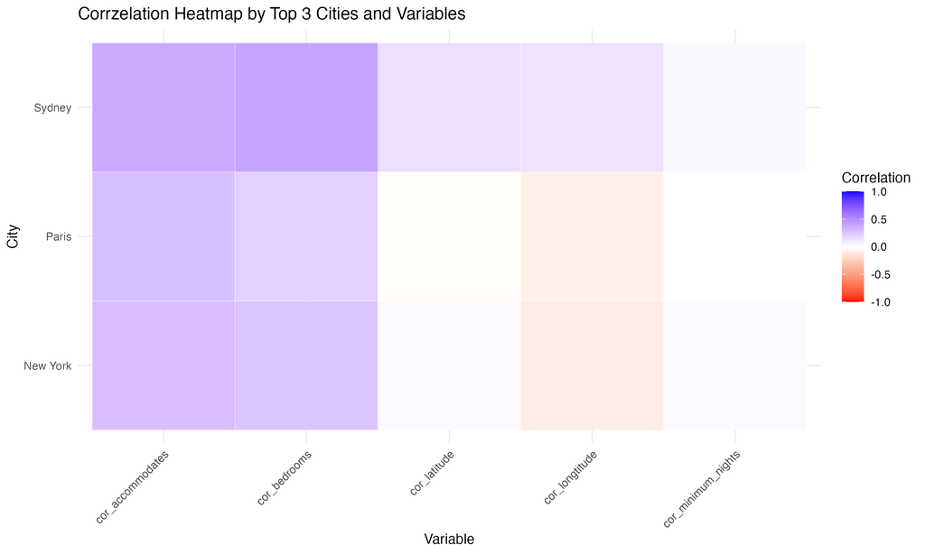

Figure 6: Visual representation of the correlation strength between price and selected variables (accommodates, bedrooms, minimum nights, latitude, longitude) across cities

The heatmap in Figure 6 highlights the **strong correlations between accommodates and bedrooms** with price, particularly in Sydney, where property size plays a more critical role in pricing compared to New York and Paris. The consistently **light shades for minimum_nights** confirm its negligible influence on price across all cities, likely driven by policy rather than market dynamics. **Geographical variables (latitude and longitude) show weak correlations** overall, with slightly darker tones in Sydney indicating a marginally greater influence of location compared to Paris and New York. This visualization reinforces that property size is the primary driver of price, while location and minimum nights have minimal impact.

## Conclusion

While the findings align with expectations in many areas, the **high variability and expansive price range in Sydney**, coupled with its stronger geographical correlations, raise questions about the underlying drivers of this market’s pricing patterns. These differences hint at unique regional dynamics that warrant further exploration.

For future work, a logical next step would be to analyze the **correlation between each amenity and listing price**, particularly in Paris, to understand which amenities add the most value. This could be achieved by extending the current data transformation to compute point-biserial correlations. Additionally, **regression modeling** could provide a more holistic understanding of how multiple variables—such as property size, amenities, and location—interact to influence price. Lastly, **exploring categorical variables**, such as property type or superhost status, could uncover further nuances in Airbnb’s pricing dynamics.